# Water Temperature logger

Monitoring the Renaturation process of the Aa river in Münster Unmmanned Aerial Systems

senseBox group

July 12, 2018

## Introduction

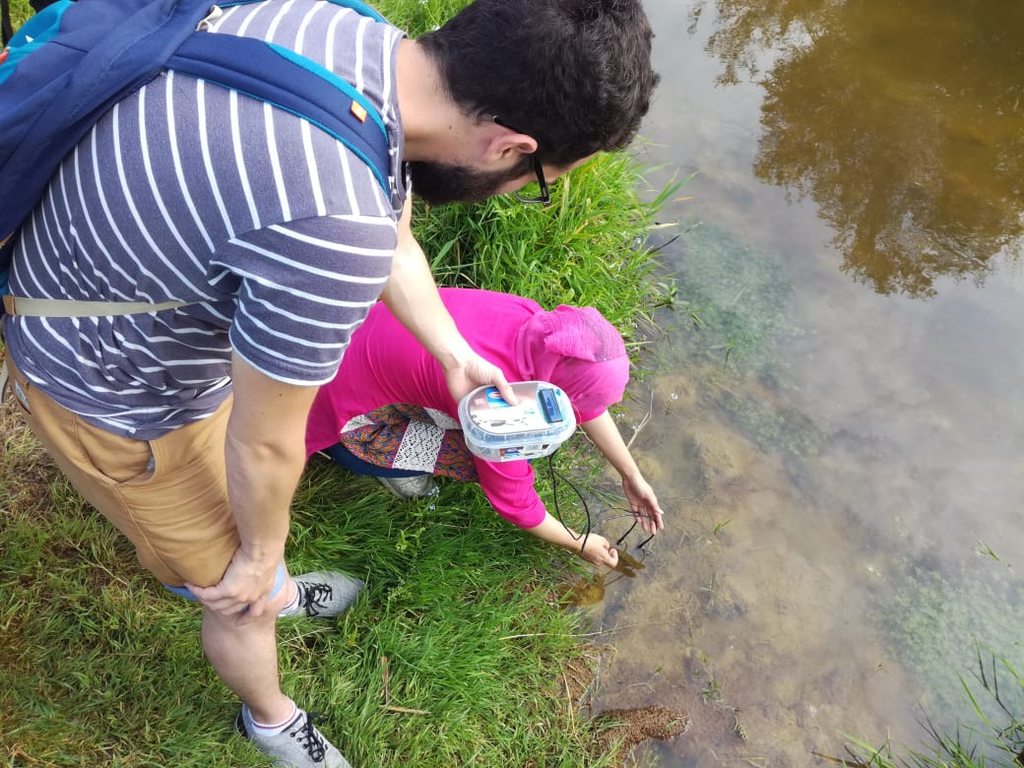

**Fig. 1:** Water temperature logger on the field

## Materials

To build this logger, as well as the other loggers for the current project, we made use of the [senseBox:edu toolkit](https://sensebox.de/en/products). For this project, we used the previous senseBox version, therefore, the documentation on the site might have changed, but is still supported. The senseBox used is based on an [Arduino Genuino Uno board](https://www.arduino.cc/en/Guide/BoardAnatomy), on which, an user-friendly and easy-to-learn programming language can be used to configure the logger. The code used for this particular logger can be found on the section Arduino code.

The materials to build the logger are listed below:

- senseBox:edu box items:
  - Arduino Genuino Uno board
  - Breadboard
  - Jumper wires
  - USB cable
  - AA battery holder
- 2 [DS18b20](https://cdn.sparkfun.com/datasheets/Sensors/Temp/DS18B20.pdf) Waterproof Temperature sensor
- DFR0009 LCD Keypad shield
- 6 AA batteries

Two water temperature sensors were used, in case of failure of one.

## Wiring

The following figure illustrates the wiring of the logger. The illustration was made with the [Fritzing](http://fritzing.org/home/) software.

[figure not shown]

**Fig. 2:** Water temperature logger wiring

## Arduino code

```r
/*
 * Water temperature data logger saves to an SD card with a timestamp for each record
 *
 * senseBox Group
 * Unmanned Aerial Systems
 * Geospatial Technologies MSc.
 *
 * Institute for Geoinformatics, University of Muenster
 * May. 2018
*/


// First we include the libraries
#include <OneWire.h>
#include <DallasTemperature.h>
#include <LiquidCrystal.h>

//Pin assignments for DFRobot LCD Keypad Shield
LiquidCrystal lcd(8, 9, 4, 5, 6, 7);

// Data wire is plugged into pin 2 on the Arduino
#define ONE_WIRE_BUS 2

// Setup a oneWire instance to communicate with any OneWire devices
// (not just Maxim/Dallas temperature ICs)
OneWire oneWire(ONE_WIRE_BUS);

// Pass our oneWire reference to Dallas Temperature.
DallasTemperature sensors(&oneWire);


void setup() {
  //LCD configuration
  lcd.begin(16, 2);
  lcd.clear();
  lcd.setCursor(0, 0);
  lcd.print("senseBox Group 2018");
  lcd.setCursor(0, 1);
  lcd.print(" Water Temperature");
// scroll 13 positions (string length) to the left
  // to move it offscreen left:
  for (int positionCounter = 0; positionCounter < 13; positionCounter++) {
    // scroll one position left:
    lcd.scrollDisplayLeft();
    // wait a bit:
    delay(300);
  }

  // scroll 29 positions (string length + display length) to the right
  // to move it offscreen right:
  for (int positionCounter = 0; positionCounter < 29; positionCounter++) {
    // scroll one position right:
    lcd.scrollDisplayRight();
    // wait a bit:
    delay(300);
  }

  // scroll 16 positions (display length + string length) to the left
  // to move it back to center:
  for (int positionCounter = 0; positionCounter < 16; positionCounter++) {
    // scroll one position left:
    lcd.scrollDisplayLeft();
    // wait a bit:
    delay(300);
  }

  // delay at the end of the full loop:
  delay(1000);



  // rtc.set(0, 32, 13, 18, 5, 2018); // 13:32:00 18.05.2018 Only use one time
  rtc.start();
  Serial.begin(9600);
  while (!Serial) {
    ;
  }
}

void loop() {

   // call sensors.requestTemperatures() to issue a global temperature
   // request to all devices on the bus
    sensors.requestTemperatures(); // Send the command to get temperature readings

    Serial.print("Temperature 0: ");
    Serial.println(sensors.getTempCByIndex(0));
    Serial.print("Temperature 1: ");
    Serial.println(sensors.getTempCByIndex(1));

    lcd.clear();
    lcd.setCursor(0, 0);
    lcd.print("Temp 0: ");
    lcd.print(sensors.getTempCByIndex(0));
    lcd.setCursor(0, 1);
    lcd.print("Temp 1: ");
    lcd.print(sensors.getTempCByIndex(1));

    // Why "byIndex"?
    // You can have more than one DS18B20 on the same bus.
    // 0 refers to the first IC on the wire
  delay(5000);

}
```